# Compare H3K27ac with gene expression (RNAseq) III

last changed: 2023-08-29

# Gene Set Enrichment Analysis

## Data processing

First, the results from the enrichment analysis are loaded with the gene coding peaks within 1kb from the TSS. Here, a dataframe with one column containing the geneIDs and the other one with the corresponding cluster is required.

```r
> peak.list.cod.1kb <- readRDS("./../Enrichment_analysis/Data/peaks_H3ac_cod1kb.rds")
> lapply(peak.list.cod.1kb, head)
```

```
## $cluster_1
##    chr   start     end strand      genome_anno gene_symbol gene_entrez
## 1 chr1  998679 1002226      . Promoter (<=1kb)       ISG15        9636
## 2 chr1 1204698 1205972      . Promoter (<=1kb)    TNFRSF18        8784
## 3 chr1 1207150 1209839      . Promoter (<=1kb)    TNFRSF18        8784
## 4 chr1 2131447 2134275      . Promoter (<=1kb)       PRKCZ        5590
## 5 chr1 2193311 2195820      . Promoter (<=1kb)      FAAP20      199990
## 6 chr1 3471129 3472582      . Promoter (<=1kb)    ARHGEF16       27237
##   distanceToTSS    transcriptId  geneId_ensembl
## 1             0 ENST00000624697 ENSG00000187608
## 2             0 ENST00000486728 ENSG00000186891
## 3          -558 ENST00000379268 ENSG00000186891
## 4             0 ENST00000471018 ENSG00000067606
## 5             0 ENST00000400919 ENSG00000162585
## 6             0 ENST00000464620 ENSG00000130762
```

[output cut: 32 more lines]

```r
> names(peak.list.cod.1kb) <- 1:3
> df.peaks <- melt(peak.list.cod.1kb, variable.factor = T)
> colnames(df.peaks)[11] <- "cluster"
> paged_table(df.peaks)
```

| chr | start | end | strand | genome_anno | gene_symbol | gene_entrez | distanceToTSS | transcriptId | geneId_ensembl | cluster |
| --- | --- | --- | --- | --- | --- | --- | --- | --- | --- | --- |
| chr1 | 998679 | 1002226 | . | Promoter (<=1kb) | ISG15 | 9636 | 0 | ENST00000624697 | ENSG00000187608 | 1 |
| chr1 | 1204698 | 1205972 | . | Promoter (<=1kb) | TNFRSF18 | 8784 | 0 | ENST00000486728 | ENSG00000186891 | 1 |
| chr1 | 1207150 | 1209839 | . | Promoter (<=1kb) | TNFRSF18 | 8784 | -558 | ENST00000379268 | ENSG00000186891 | 1 |
| chr1 | 2131447 | 2134275 | . | Promoter (<=1kb) | PRKCZ | 5590 | 0 | ENST00000471018 | ENSG00000067606 | 1 |
| chr1 | 2193311 | 2195820 | . | Promoter (<=1kb) | FAAP20 | 199990 | 0 | ENST00000400919 | ENSG00000162585 | 1 |
| chr1 | 3471129 | 3472582 | . | Promoter (<=1kb) | ARHGEF16 | 27237 | 0 | ENST00000464620 | ENSG00000130762 | 1 |
| chr1 | 3495438 | 3497023 | . | Promoter (<=1kb) | MEGF6 | 1953 | 0 | ENST00000491842 | ENSG00000162591 | 1 |
| chr1 | 3651515 | 3653291 | . | Promoter (<=1kb) | TP73 | 7161 | 0 | ENST00000378295 | ENSG00000078900 | 1 |
| chr1 | 6260093 | 6261500 | . | Promoter (<=1kb) | GPR153 | 387509 | 0 | ENST00000377893 | ENSG00000158292 | 1 |
| chr1 | 6489342 | 6492512 | . | Promoter (<=1kb) | PLEKHG5 | 57449 | 0 | ENST00000377725 | ENSG00000171680 | 1 |

[output cut: 3007 more lines]

```r
> cluster <- select(df.peaks, cluster, geneId_ensembl)
> head(cluster)
```

```
##   cluster  geneId_ensembl
## 1       1 ENSG00000187608
## 2       1 ENSG00000186891
## 3       1 ENSG00000186891
## 4       1 ENSG00000067606
## 5       1 ENSG00000162585
## 6       1 ENSG00000130762
```

Next, the RNAseq results were loaded and transformed into a named vector.

```r
> results <- read.delim("./Data/res_RNAseq.txt")
> head(results)
```

```
##    baseMean log2FoldChange     lfcSE       pvalue         padj ensembl_gene_id
## 1  677.4716     -1.3482987 0.1463069 1.329537e-22 1.793412e-18 ENSG00000148677
## 2 1656.2673      1.2190478 0.1491956 1.456746e-18 9.825025e-15 ENSG00000056558
## 3  423.6430      1.2695262 0.1601643 9.813757e-18 4.412592e-14 ENSG00000204839
## 4 5203.4824     -1.1736041 0.1532902 9.133538e-17 2.464046e-13 ENSG00000130164
## 5  236.8364      1.4096339 0.1847334 8.182703e-17 2.464046e-13 ENSG00000182324
## 6 1141.8448     -0.9331893 0.1241679 2.809985e-16 6.317315e-13 ENSG00000158106
##   hgnc_symbol   gene_biotype
## 1      ANKRD1 protein_coding
## 2       TRAF1 protein_coding
## 3       MROH6 protein_coding
## 4        LDLR protein_coding
## 5      KCNJ14 protein_coding
## 6       RHPN1 protein_coding
```

```r
> gene.list <- results$log2FoldChange
> names(gene.list) <- results$ensembl_gene_id
> head(gene.list)
```

```
## ENSG00000148677 ENSG00000056558 ENSG00000204839 ENSG00000130164 ENSG00000182324
##      -1.3482987       1.2190478       1.2695262      -1.1736041       1.4096339
## ENSG00000158106
##      -0.9331893
```

These results were then filtered for only protein coding genes.

```r
> results.cod <- results[which(results$gene_biotype == "protein_coding"), ]
> paged_table(results.cod)
```

|  | baseMean | log2FoldChange | lfcSE | pvalue | padj | ensembl_gene_id | hgnc_symbol | gene_biotype |
| --- | --- | --- | --- | --- | --- | --- | --- | --- |
| 1 | 6.774716e+02 | -1.34829871 | 0.14630693 | 1.329537e-22 | 1.793412e-18 | ENSG00000148677 | ANKRD1 | protein_coding |
| 2 | 1.656267e+03 | 1.21904785 | 0.14919555 | 1.456746e-18 | 9.825025e-15 | ENSG00000056558 | TRAF1 | protein_coding |
| 3 | 4.236430e+02 | 1.26952616 | 0.16016435 | 9.813757e-18 | 4.412592e-14 | ENSG00000204839 | MROH6 | protein_coding |
| 4 | 5.203482e+03 | -1.17360407 | 0.15329023 | 9.133538e-17 | 2.464046e-13 | ENSG00000130164 | LDLR | protein_coding |
| 5 | 2.368364e+02 | 1.40963394 | 0.18473344 | 8.182703e-17 | 2.464046e-13 | ENSG00000182324 | KCNJ14 | protein_coding |
| 6 | 1.141845e+03 | -0.93318935 | 0.12416794 | 2.809985e-16 | 6.317315e-13 | ENSG00000158106 | RHPN1 | protein_coding |
| 7 | 7.112047e+01 | 2.17498079 | 0.29998032 | 4.723913e-16 | 9.102981e-13 | ENSG00000188818 | ZDHHC11 | protein_coding |
| 8 | 4.523538e+02 | 1.14844616 | 0.16912524 | 4.809294e-14 | 8.109071e-11 | ENSG00000086544 | ITPKC | protein_coding |
| 9 | 5.608793e+02 | 1.16309979 | 0.17461195 | 1.126876e-13 | 1.688937e-10 | ENSG00000124225 | PMEPA1 | protein_coding |
| 10 | 3.436950e+03 | -0.61798891 | 0.10158057 | 4.610686e-12 | 6.219354e-09 | ENSG00000013588 | GPRC5A | protein_coding |

[output cut: 9990 more lines]

```r
> gene.list.cod <- results.cod$log2FoldChange
> names(gene.list.cod) <- results.cod$ensembl_gene_id
```

Lastly, the log2 fold change and the adjusted p-values were used to calculate a robust sorting score for the RNAseq gene list.

```r
> log2fold.adj.p <- results.cod$log2FoldChange * (-log10(results.cod$padj))
> log2fold.adj.p[is.na(log2fold.adj.p)] <- 0
> names(log2fold.adj.p) <- results.cod$ensembl_gene_id
> log2fold.adj.p <- sort(log2fold.adj.p, decreasing = T)
```

The sorted vector when then used to perform a GSEA.

```r
> gse.adj.p <- GSEA(log2fold.adj.p, TERM2GENE = cluster, pvalueCutoff = 1,
+                   pAdjustMethod = "BH", maxGSSize = 2000)
>
> gse.adj.p@result[, -11]
```

```
##   ID Description setSize enrichmentScore       NES    pvalue  p.adjust
## 3  3           3     368      -0.5701033 -1.097347 0.2442244 0.3539326
## 2  2           2     914      -0.5011365 -1.036775 0.3114754 0.3539326
## 1  1           1    1566      -0.4698836 -1.018730 0.3539326 0.3539326
##      qvalue rank                  leading_edge
## 3 0.3539326  744   tags=9%, list=4%, signal=9%
## 2 0.3539326  586   tags=5%, list=3%, signal=6%
## 1 0.3539326 1159 tags=10%, list=6%, signal=11%
```

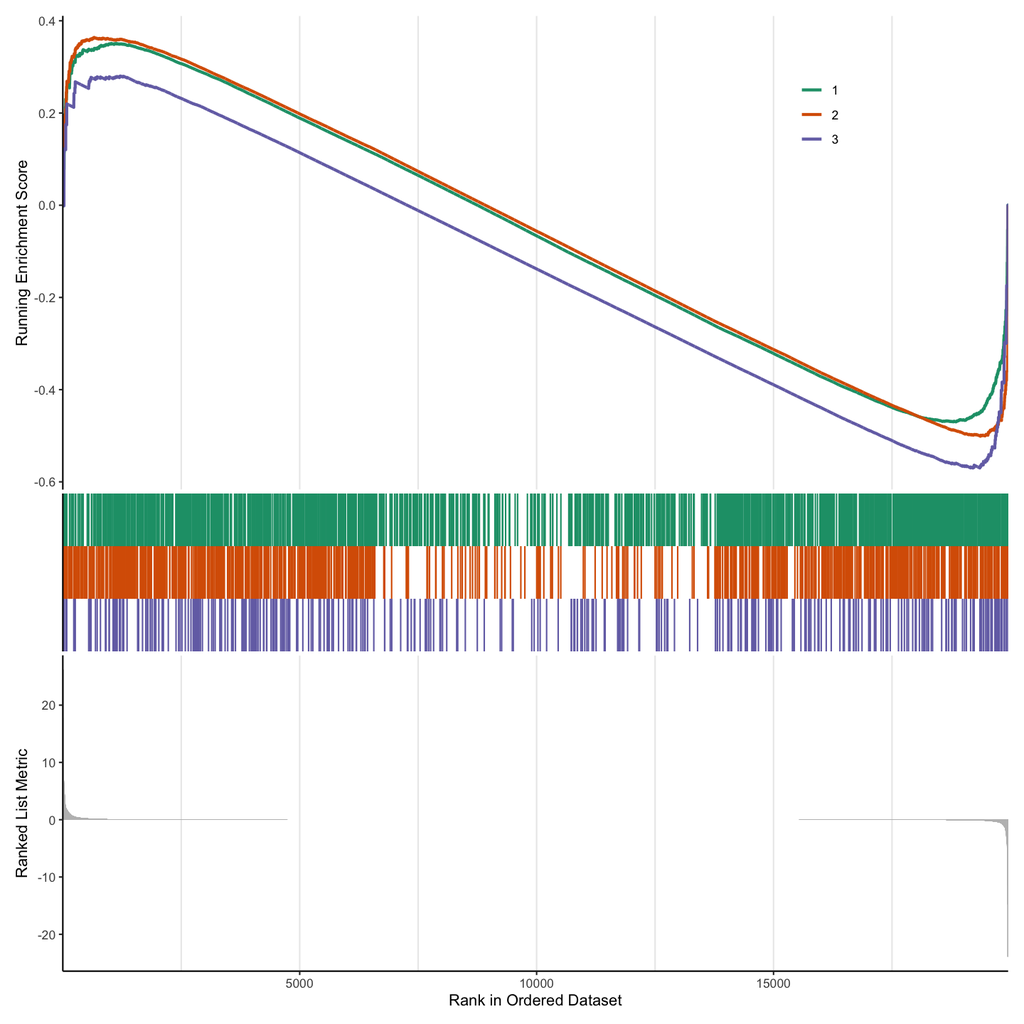

```r
> col <- brewer.pal(n = 8, name = "Dark2")
> gseaplot2(gse.adj.p, geneSetID = 1:3, color = col[1:3])
```

# Correlation between H3K27ac and RNAseq

## Data processing

First, the data (rlog-transformed DESeq data sets) were loaded for H3k27ac and RNAseq. Here, the sample for Exp2 at 0 hpi was removed, because it was identified as an outlier in a PCA (not shown).

```r
> #RNAseq:
> load(file = "./Data/rlog_RNAseq.rda")
>
> m.RNAseq <- assay(rld)
> info.RNAseq <- data.frame(colData(rld))
> info.RNAseq <- filter(info.RNAseq, name != "Exp2_0")
> paged_table(info.RNAseq)
```

|  | ID | name | condition | replica | Time | sizeFactor |
| --- | --- | --- | --- | --- | --- | --- |
| Exp1_05h | Exp1_05h | Exp1_05h | 0.5hpi | R1 | 0.5 | 0.8762770 |
| Exp1_0 | Exp1_0 | Exp1_0 | 0hpi | R1 | 0 | 1.0771883 |
| Exp1_1h | Exp1_1h | Exp1_1h | 1hpi | R1 | 1 | 0.9178595 |
| Exp1_2h | Exp1_2h | Exp1_2h | 2hpi | R1 | 2 | 0.9673782 |
| Exp1_4h | Exp1_4h | Exp1_4h | 4hpi | R1 | 4 | 0.6546086 |
| Exp2_05h | Exp2_05h | Exp2_05h | 0.5hpi | R2 | 0.5 | 0.8440820 |
| Exp2_1h | Exp2_1h | Exp2_1h | 1hpi | R2 | 1 | 2.8553225 |
| Exp2_2h | Exp2_2h | Exp2_2h | 2hpi | R2 | 2 | 1.0124080 |
| Exp2_4h | Exp2_4h | Exp2_4h | 4hpi | R2 | 4 | 0.6864945 |

```r
> m.RNAseq <- m.RNAseq[, info.RNAseq$name]
> head(m.RNAseq)
```

[output not shown]

```r
> #H3K27ac:
> rlog.heat <- readRDS(file = "./../Significance_testing/Data/rlog_H3K27ac_sig.rds")
>
> info.H3ac <- data.frame(colData(rlog.heat))
> paged_table(info.H3ac)
```

|  | construct | replica | time | sizeFactor |
| --- | --- | --- | --- | --- |
| U2OS31_T0h_Rep1 | U2OS31 | Rep1 | 0 | 0.9713745 |
| U2OS31_T0h_Rep2 | U2OS31 | Rep2 | 0 | 0.9677638 |
| U2OS31_T0h_Rep3 | U2OS31 | Rep3 | 0 | 1.4070125 |
| U2OS31_T1h_Rep1 | U2OS31 | Rep1 | 1 | 1.3427846 |
| U2OS31_T1h_Rep2 | U2OS31 | Rep2 | 1 | 1.3689437 |
| U2OS31_T1h_Rep3 | U2OS31 | Rep3 | 1 | 1.3748857 |
| U2OS31_T2h_Rep1 | U2OS31 | Rep1 | 2 | 0.9648885 |
| U2OS31_T2h_Rep2 | U2OS31 | Rep2 | 2 | 1.3894730 |
| U2OS31_T4h_Rep1 | U2OS31 | Rep1 | 4 | 1.0879097 |
| U2OS31_T4h_Rep2 | U2OS31 | Rep2 | 4 | 1.2114263 |

[output cut: 12 more lines]

```r
> m.H3ac <- assay(rlog.heat)
> head(m.H3ac)
```

```
##                      U2OS31_T0h_Rep1 U2OS31_T0h_Rep2 U2OS31_T0h_Rep3
## chr1:777858-779502          6.644882        7.047764        6.843831
## chr1:998679-1002226         7.498502        8.017057        7.874621
## chr1:1062482-1064839        6.936592        7.241185        7.003333
## chr1:1200210-1201807        6.934436        7.513163        7.134582
## chr1:1202874-1203283        3.356625        3.822526        3.791844
## chr1:1204698-1205972        4.254665        4.742891        4.917207
##                      U2OS31_T1h_Rep1 U2OS31_T1h_Rep2 U2OS31_T1h_Rep3
## chr1:777858-779502          6.517474        6.703328        6.873693
## chr1:998679-1002226         7.998243        8.467343        8.302465
## chr1:1062482-1064839        7.626672        7.742398        7.666093
## chr1:1200210-1201807        7.565851        7.760794        7.677449
## chr1:1202874-1203283        3.934671        4.003246        4.427764
## chr1:1204698-1205972        5.122689        5.762440        5.675096
##                      U2OS31_T2h_Rep1 U2OS31_T2h_Rep2 U2OS31_T4h_Rep1
## chr1:777858-779502          6.640883        6.517778        7.088908
## chr1:998679-1002226         8.054719        7.931793        7.407744
## chr1:1062482-1064839        7.485299        7.034059        7.056250
## chr1:1200210-1201807        7.743524        7.840957        7.348425
## chr1:1202874-1203283        4.307967        4.287953        3.557889
## chr1:1204698-1205972        5.234419        5.331420        4.751368
##                      U2OS31_T4h_Rep2 U2OS33_T0h_Rep1 U2OS33_T0h_Rep2
## chr1:777858-779502          6.653240        7.191532        7.220966
## chr1:998679-1002226         6.942857        7.627258        8.156514
## chr1:1062482-1064839        6.902423        6.772283        6.647448
## chr1:1200210-1201807        7.378682        7.085342        7.456336
## chr1:1202874-1203283        3.467119        3.387016        3.619754
## chr1:1204698-1205972        4.530288        4.591392        5.044981
##                      U2OS33_T0h_Rep3 U2OS33_T1h_Rep1 U2OS33_T1h_Rep2
## chr1:777858-779502          6.802851        7.140648        7.189506
## chr1:998679-1002226         7.983411        8.777242        9.068580
## chr1:1062482-1064839        6.585536        7.619277        7.763149
## chr1:1200210-1201807        6.967209        7.775634        8.128662
## chr1:1202874-1203283        3.725291        4.279163        4.098830
## chr1:1204698-1205972        4.590939        5.295389        5.532942
##                      U2OS33_T1h_Rep3 U2OS33_T2h_Rep1 U2OS33_T2h_Rep2
## chr1:777858-779502          6.831799        6.866234        6.606008
## chr1:998679-1002226         8.777677        8.763022        8.849320
## chr1:1062482-1064839        7.778628        7.525321        7.322127
## chr1:1200210-1201807        7.896455        7.767084        7.746612
## chr1:1202874-1203283        4.437457        4.206605        4.138575
## chr1:1204698-1205972        5.649694        5.825150        5.600117
##                      U2OS33_T2h_Rep3 U2OS33_T4h_Rep1 U2OS33_T4h_Rep2
## chr1:777858-779502          6.513053        6.555047        7.007727
## chr1:998679-1002226         8.339706        7.537214        7.723678
## chr1:1062482-1064839        6.921511        7.219436        6.845753
## chr1:1200210-1201807        7.732785        7.415408        7.178515
## chr1:1202874-1203283        4.006166        3.591726        3.267218
## chr1:1204698-1205972        5.604686        5.088697        4.895844
##                      U2OS33_T4h_Rep3
## chr1:777858-779502          6.456581
## chr1:998679-1002226         7.689625
## chr1:1062482-1064839        6.742765
## chr1:1200210-1201807        7.139855
## chr1:1202874-1203283        3.315074
## chr1:1204698-1205972        5.347766
```

Since the two experiments have different time points, the matrices need to be filtered for the required time points. Then, the median over the replicates can be calculated. For the H3K27ac the matrix was adittionally seperated by construct.

```r
> times <- c(0, 1, 2, 4)
>
> # RNAseq:
> m.RNAseq.median <- matrix(data = NA, ncol = 4, nrow = nrow(m.RNAseq))
> rownames(m.RNAseq.median) <- rownames(m.RNAseq)
> colnames(m.RNAseq.median) <- c("T0h", "T1h", "T2h", "T4h")
>
> for (t in 1:4) {
+   ind <- which(info.RNAseq[, "Time"] == times[t])
+   if (t == 1)
+     medians <- m.RNAseq[, ind]
+   else
+     medians <- apply(m.RNAseq[,  ind], 1, median)
+   m.RNAseq.median[, t] <- medians
+ }
>
> saveRDS(m.RNAseq.median, "./Data/m_RNAseq_median.rds")
> head(m.RNAseq.median)
```

```
##                       T0h       T1h       T2h       T4h
## ENSG00000243485  0.000000  0.000000  0.000000  0.000000
## ENSG00000237613  0.000000  0.000000  0.000000  0.000000
## ENSG00000186092  0.000000  0.000000  0.000000  0.000000
## ENSG00000238009 -2.129442 -2.131484 -2.129933 -2.124332
## ENSG00000239945  0.000000  0.000000  0.000000  0.000000
## ENSG00000241599  0.000000  0.000000  0.000000  0.000000
```

```r
> # H3K27ac:
> ind.H3.1 <- which(info.H3ac$construct == "U2OS31")
> ind.H3.3 <- which(info.H3ac$construct == "U2OS33")
>
> m.H3.1ac <- m.H3ac[ ,ind.H3.1]
> m.H3.3ac <- m.H3ac[ ,ind.H3.3]
>
> m.H3.1ac.median <- matrix(data = NA, ncol = 4, nrow = nrow(m.H3.1ac))
> rownames(m.H3.1ac.median) <- rownames(m.H3.1ac)
> colnames(m.H3.1ac.median) <- c("T0h", "T1h", "T2h", "T4h")
>
> m.H3.3ac.median <- m.H3.1ac.median
>
> for (t in 1:4) {
+   t.0.H3.1 <- which(info.H3ac[ind.H3.1, "time"] == times[t])
+   medians <- apply(m.H3.1ac[,  t.0.H3.1], 1, median)
+   m.H3.1ac.median[, t] <- medians
+ }
>
> for (t in 1:4) {
+   t.0.H3.3 <- which(info.H3ac[ind.H3.3, "time"] == times[t])
+   medians <- apply(m.H3.3ac[,  t.0.H3.3], 1, median)
+   m.H3.3ac.median[, t] <- medians
+ }
>
> saveRDS(m.H3.1ac.median, "./Data/m_H3.1K27ac_median.rds")
> saveRDS(m.H3.3ac.median, "./Data/m_H3.3K27ac_median.rds")
> head(m.H3.1ac.median)
```

```
##                           T0h      T1h      T2h      T4h
## chr1:777858-779502   6.843831 6.703328 6.579330 6.871074
## chr1:998679-1002226  7.874621 8.302465 7.993256 7.175300
## chr1:1062482-1064839 7.003333 7.666093 7.259679 6.979337
## chr1:1200210-1201807 7.134582 7.677449 7.792240 7.363553
## chr1:1202874-1203283 3.791844 4.003246 4.297960 3.512504
## chr1:1204698-1205972 4.742891 5.675096 5.282920 4.640828
```

```r
> head(m.H3.3ac.median)
```

```
##                           T0h      T1h      T2h      T4h
## chr1:777858-779502   7.191532 7.140648 6.606008 6.555047
## chr1:998679-1002226  7.983411 8.777677 8.763022 7.689625
## chr1:1062482-1064839 6.647448 7.763149 7.322127 6.845753
## chr1:1200210-1201807 7.085342 7.896455 7.746612 7.178515
## chr1:1202874-1203283 3.619754 4.279163 4.138575 3.315074
## chr1:1204698-1205972 4.591392 5.532942 5.604686 5.088697
```

Further, the annotated peak list is required and needs to be sorted and filtered to only contain genes/peaks contained in both experiments.

```r
> peaks.cod <- readRDS("./../Enrichment_analysis/Data/peaks_H3ac_cod1kb.rds")
> lapply(peaks.cod, head)
```

```
## $cluster_1
##    chr   start     end strand      genome_anno gene_symbol gene_entrez
## 1 chr1  998679 1002226      . Promoter (<=1kb)       ISG15        9636
## 2 chr1 1204698 1205972      . Promoter (<=1kb)    TNFRSF18        8784
## 3 chr1 1207150 1209839      . Promoter (<=1kb)    TNFRSF18        8784
## 4 chr1 2131447 2134275      . Promoter (<=1kb)       PRKCZ        5590
## 5 chr1 2193311 2195820      . Promoter (<=1kb)      FAAP20      199990
## 6 chr1 3471129 3472582      . Promoter (<=1kb)    ARHGEF16       27237
##   distanceToTSS    transcriptId  geneId_ensembl
## 1             0 ENST00000624697 ENSG00000187608
## 2             0 ENST00000486728 ENSG00000186891
## 3          -558 ENST00000379268 ENSG00000186891
## 4             0 ENST00000471018 ENSG00000067606
## 5             0 ENST00000400919 ENSG00000162585
## 6             0 ENST00000464620 ENSG00000130762
```

[output cut: 32 more lines]

```r
> peaks <- rbind(peaks.cod[[1]], peaks.cod[[2]], peaks.cod[[3]])
> peaks <- mutate(peaks, peak_pos = paste0(peaks$chr, ":", peaks$start, "-", peaks$end))
> paged_table(peaks)
```

| chr | start | end | strand | genome_anno | gene_symbol | gene_entrez | distanceToTSS | transcriptId | geneId_ensembl | peak_pos |
| --- | --- | --- | --- | --- | --- | --- | --- | --- | --- | --- |
| chr1 | 998679 | 1002226 | . | Promoter (<=1kb) | ISG15 | 9636 | 0 | ENST00000624697 | ENSG00000187608 | chr1:998679-1002226 |
| chr1 | 1204698 | 1205972 | . | Promoter (<=1kb) | TNFRSF18 | 8784 | 0 | ENST00000486728 | ENSG00000186891 | chr1:1204698-1205972 |
| chr1 | 1207150 | 1209839 | . | Promoter (<=1kb) | TNFRSF18 | 8784 | -558 | ENST00000379268 | ENSG00000186891 | chr1:1207150-1209839 |
| chr1 | 2131447 | 2134275 | . | Promoter (<=1kb) | PRKCZ | 5590 | 0 | ENST00000471018 | ENSG00000067606 | chr1:2131447-2134275 |
| chr1 | 2193311 | 2195820 | . | Promoter (<=1kb) | FAAP20 | 199990 | 0 | ENST00000400919 | ENSG00000162585 | chr1:2193311-2195820 |
| chr1 | 3471129 | 3472582 | . | Promoter (<=1kb) | ARHGEF16 | 27237 | 0 | ENST00000464620 | ENSG00000130762 | chr1:3471129-3472582 |
| chr1 | 3495438 | 3497023 | . | Promoter (<=1kb) | MEGF6 | 1953 | 0 | ENST00000491842 | ENSG00000162591 | chr1:3495438-3497023 |
| chr1 | 3651515 | 3653291 | . | Promoter (<=1kb) | TP73 | 7161 | 0 | ENST00000378295 | ENSG00000078900 | chr1:3651515-3653291 |
| chr1 | 6260093 | 6261500 | . | Promoter (<=1kb) | GPR153 | 387509 | 0 | ENST00000377893 | ENSG00000158292 | chr1:6260093-6261500 |
| chr1 | 6489342 | 6492512 | . | Promoter (<=1kb) | PLEKHG5 | 57449 | 0 | ENST00000377725 | ENSG00000171680 | chr1:6489342-6492512 |

[output cut: 3007 more lines]

```r
> peaks.RNAseq <- intersect(peaks$geneId_ensembl, rownames(m.RNAseq))
>
> peaks.both <- peaks[which(peaks$geneId_ensembl %in% peaks.RNAseq), ]
>
> m.H3.1ac.med.cod <- m.H3.1ac.median[peaks.both$peak_pos, ]
> m.H3.3ac.med.cod <- m.H3.3ac.median[peaks.both$peak_pos, ]
> m.RNAseq.med.cod <- m.RNAseq.median[peaks.both$geneId_ensembl, ]
```

Next, the correlation was calculated for H3.1/H3.3 K27ac and RNAseq, as follows:

```r
> # correlation for H3.1K27ac and RNAseq
> cor.H3.1ac.RNAseq <- c()
>
> for (i in 1:nrow(peaks.both)) {
+   curr.corr <- cor(m.H3.1ac.med.cod[i, ], m.RNAseq.med.cod[i, ], method = "pearson")
+   cor.H3.1ac.RNAseq <- c(cor.H3.1ac.RNAseq, curr.corr)
+ }
> names(cor.H3.1ac.RNAseq) <- rownames(m.RNAseq.med.cod)
> head(cor.H3.1ac.RNAseq)
```

```
## ENSG00000187608 ENSG00000186891 ENSG00000186891 ENSG00000067606 ENSG00000162585
##      -0.9273149      -0.9462638      -0.8392339      -0.5762918      -0.7294896
## ENSG00000130762
##       0.4951330
```

```r
> # correlation for H3.3K27ac and RNAseq
> cor.H3.3ac.RNAseq <- c()
>
> for (i in 1:nrow(peaks.both)) {
+   curr.corr <- cor(m.H3.3ac.med.cod[i, ], m.RNAseq.med.cod[i, ], method = "pearson")
+   cor.H3.3ac.RNAseq <- c(cor.H3.3ac.RNAseq, curr.corr)
+ }
> names(cor.H3.3ac.RNAseq) <- rownames(m.RNAseq.med.cod)
> head(cor.H3.3ac.RNAseq)
```

```
## ENSG00000187608 ENSG00000186891 ENSG00000186891 ENSG00000067606 ENSG00000162585
##      -0.8038803      -0.5445962      -0.5723416      -0.2391592      -0.6745609
## ENSG00000130762
##       0.2160730
```

To plot the correlation between H3K27ac and RNAseq for each cluster the data was transformed into a dataframe, containing the required factors/values. The correlation was then plotted using `geom_density`.

```r
> cor.H3ac.RNAseq.NAs <- data.frame(U2OS31 = cor.H3.1ac.RNAseq,
+                                   U2OS33 = cor.H3.3ac.RNAseq,
+                                   gene = rownames(m.RNAseq.med.cod),
+                                   peak = rownames(m.H3.1ac.med.cod))
> cor.H3ac.RNAseq <- na.omit(cor.H3ac.RNAseq.NAs)
>
> cor.H3ac.RNAseq.NAs <- data.frame(U2OS31 = cor.H3.1ac.RNAseq,
+                                   U2OS33 = cor.H3.3ac.RNAseq,
+                                   gene = rownames(m.RNAseq.med.cod),
+                                   peak = rownames(m.H3.1ac.med.cod))
> cor.H3ac.RNAseq <- na.omit(cor.H3ac.RNAseq.NAs)
>
> peak.pos.clus <- lapply(peaks.cod, function(x)
+   mutate(x, peak_pos = paste0(x$chr, ":", x$start, "-", x$end))
+   )
>
> cor.cluster <- mutate(cor.H3ac.RNAseq, cluster = NA)
>
> for (step in 1:3) {
+   ind <- peak.pos.clus[[step]]$peak_pos
+   cor.cluster[which(cor.cluster$peak %in% ind), "cluster"] <- step
+ }
>
> paged_table(cor.cluster)
```

|  | U2OS31 | U2OS33 | gene | peak | cluster |
| --- | --- | --- | --- | --- | --- |
| 1 | -0.9273149045 | -0.8038802875 | ENSG00000187608 | chr1:998679-1002226 | 1 |
| 2 | -0.9462637998 | -0.5445962008 | ENSG00000186891 | chr1:1204698-1205972 | 1 |
| 3 | -0.8392339108 | -0.5723416038 | ENSG00000186891 | chr1:1207150-1209839 | 1 |
| 4 | -0.5762918014 | -0.2391592150 | ENSG00000067606 | chr1:2131447-2134275 | 1 |
| 5 | -0.7294896104 | -0.6745608843 | ENSG00000162585 | chr1:2193311-2195820 | 1 |
| 6 | 0.4951330482 | 0.2160729892 | ENSG00000130762 | chr1:3471129-3472582 | 1 |
| 7 | -0.4853732957 | -0.5122410356 | ENSG00000162591 | chr1:3495438-3497023 | 1 |
| 8 | -0.3922502458 | -0.5655951051 | ENSG00000078900 | chr1:3651515-3653291 | 1 |
| 9 | 0.9093580892 | 0.8531341248 | ENSG00000158292 | chr1:6260093-6261500 | 1 |
| 10 | -0.5177861706 | -0.0849116227 | ENSG00000171680 | chr1:6489342-6492512 | 1 |

[output cut: 2917 more lines]

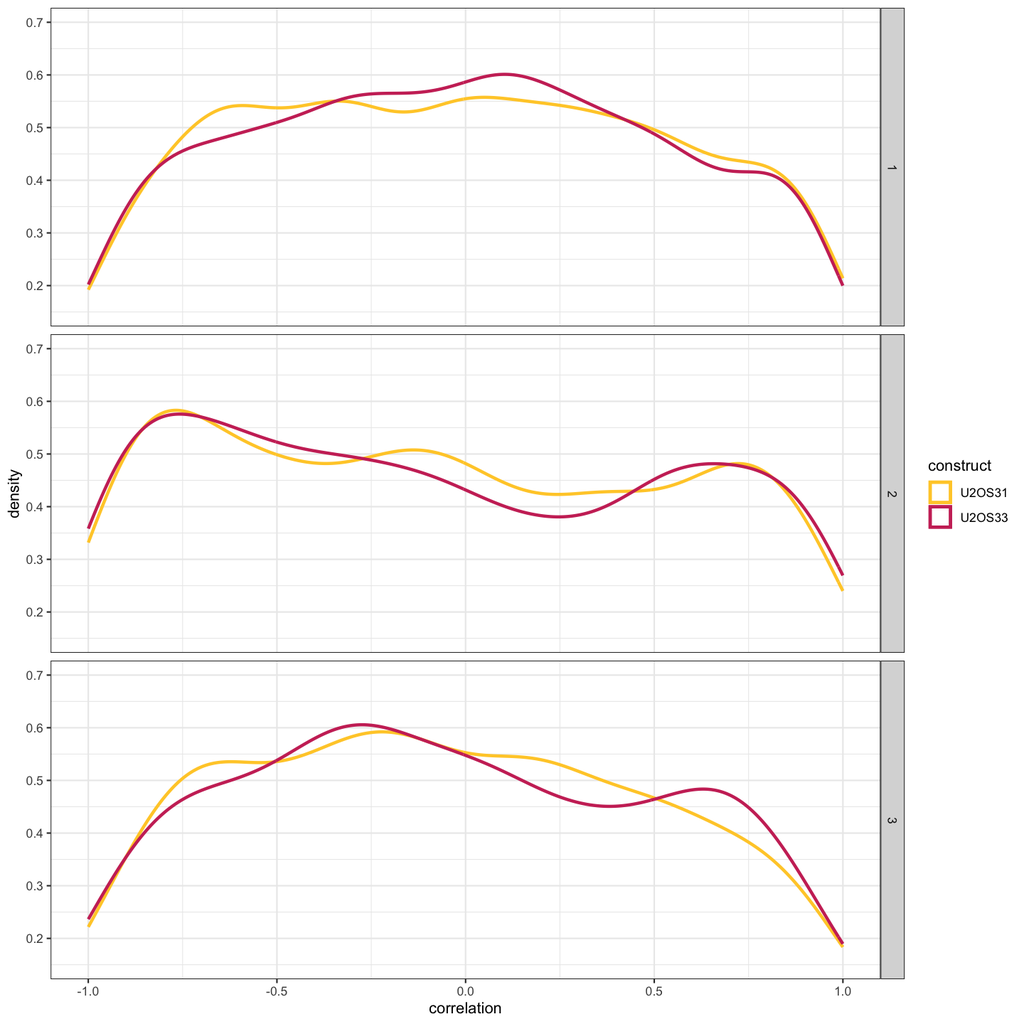

```r
> ggplot(cor.cluster) +
+   geom_density(aes(x = U2OS31, color = "U2OS31"), linewidth = 1.05) +
+   geom_density(aes(x = U2OS33, color = "U2OS33"), linewidth = 1.05) +
+   scale_color_manual(name = "construct",
+                      breaks = c("U2OS31", "U2OS33"),
+                      values = c("U2OS31" = "#FFCC33", "U2OS33" = "#CC3366")) +
+   labs(x = "correlation") +
+   coord_cartesian(ylim =  c(0.15, 0.7)) +
+   theme_bw() +
+   facet_grid(rows = cor.cluster$cluster)
```

## References - packages

- Ahlmann-Eltze C, Hickey P, Pagès H (2023). *MatrixGenerics: S4 Generic Summary Statistic Functions that Operate on Matrix-Like Objects*. doi:10.18129/B9.bioc.MatrixGenerics https://doi.org/10.18129/B9.bioc.MatrixGenerics, R package version 1.12.2, https://bioconductor.org/packages/MatrixGenerics.
- Allaire J, Xie Y, Dervieux C, McPherson J, Luraschi J, Ushey K, Atkins A, Wickham H, Cheng J, Chang W, Iannone R (2023). *rmarkdown: Dynamic Documents for R*. R package version 2.23, https://github.com/rstudio/rmarkdown. Xie Y, Allaire J, Grolemund G (2018). *R Markdown: The Definitive Guide*. Chapman and Hall/CRC, Boca Raton, Florida. ISBN 9781138359338, https://bookdown.org/yihui/rmarkdown. Xie Y, Dervieux C, Riederer E (2020). *R Markdown Cookbook*. Chapman and Hall/CRC, Boca Raton, Florida. ISBN 9780367563837, https://bookdown.org/yihui/rmarkdown-cookbook.
- Arora S, Morgan M, Carlson M, Pagès H (2023). *GenomeInfoDb: Utilities for manipulating chromosome names, including modifying them to follow a particular naming style*. doi:10.18129/B9.bioc.GenomeInfoDb https://doi.org/10.18129/B9.bioc.GenomeInfoDb, R package version 1.36.0, https://bioconductor.org/packages/GenomeInfoDb.
- Bengtsson H (2023). *matrixStats: Functions that Apply to Rows and Columns of Matrices (and to Vectors)*. R package version 1.0.0, https://CRAN.R-project.org/package=matrixStats.
- Carlson M (2023). *org.Hs.eg.db: Genome wide annotation for Human*. R package version 3.17.0.
- Huber W, Carey VJ, Gentleman R, Anders S, Carlson M, Carvalho BS, Bravo HC, Davis S, Gatto L, Girke T, Gottardo R, Hahne F, Hansen KD, Irizarry RA, Lawrence M, Love MI, MacDonald J, Obenchain V, Ole’s AK, Pag`es H, Reyes A, Shannon P, Smyth GK, Tenenbaum D, Waldron L, Morgan M (2015). “Orchestrating high-throughput genomic analysis with Bioconductor.” *Nature Methods*, *12*(2), 115-121. http://www.nature.com/nmeth/journal/v12/n2/full/nmeth.3252.html.
- Huber, W., Carey, J. V, Gentleman, R., Anders, S., Carlson, M., Carvalho, S. B, Bravo, C. H, Davis, S., Gatto, L., Girke, T., Gottardo, R., Hahne, F., Hansen, D. K, Irizarry, A. R, Lawrence, M., Love, I. M, MacDonald, J., Obenchain, V., Ole’s, K. A, Pag`es, H., Reyes, A., Shannon, P., Smyth, K. G, Tenenbaum, D., Waldron, L., Morgan, M. (2015). “Orchestrating high-throughput genomic analysis with Bioconductor.” *Nature Methods*, *12*(2), 115-121. http://www.nature.com/nmeth/journal/v12/n2/full/nmeth.3252.html.
- Lawrence M, Huber W, Pagès H, Aboyoun P, Carlson M, Gentleman R, Morgan M, Carey V (2013). “Software for Computing and Annotating Genomic Ranges.” *PLoS Computational Biology*, *9*. doi:10.1371/journal.pcbi.1003118 https://doi.org/10.1371/journal.pcbi.1003118, http://www.ploscompbiol.org/article/info%3Adoi%2F10.1371%2Fjournal.pcbi.1003118.
- Lawrence M, Huber W, Pagès H, Aboyoun P, Carlson M, Gentleman R, Morgan M, Carey V (2013). “Software for Computing and Annotating Genomic Ranges.” *PLoS Computational Biology*, *9*. doi:10.1371/journal.pcbi.1003118 https://doi.org/10.1371/journal.pcbi.1003118, http://www.ploscompbiol.org/article/info%3Adoi%2F10.1371%2Fjournal.pcbi.1003118.
- Lawrence M, Huber W, Pagès H, Aboyoun P, Carlson M, Gentleman R, Morgan M, Carey V (2013). “Software for Computing and Annotating Genomic Ranges.” *PLoS Computational Biology*, *9*. doi:10.1371/journal.pcbi.1003118 https://doi.org/10.1371/journal.pcbi.1003118, http://www.ploscompbiol.org/article/info%3Adoi%2F10.1371%2Fjournal.pcbi.1003118.
- Love MI, Huber W, Anders S (2014). “Moderated estimation of fold change and dispersion for RNA-seq data with DESeq2.” *Genome Biology*, *15*, 550. doi:10.1186/s13059-014-0550-8 https://doi.org/10.1186/s13059-014-0550-8.
- Makowski D, Lüdecke D, Patil I, Thériault R, Ben-Shachar M, Wiernik B (2023). “Automated Results Reporting as a Practical Tool to Improve Reproducibility and Methodological Best Practices Adoption.” *CRAN*. https://easystats.github.io/report/.
- Morgan M, Obenchain V, Hester J, Pagès H (2023). *SummarizedExperiment: SummarizedExperiment container*. doi:10.18129/B9.bioc.SummarizedExperiment https://doi.org/10.18129/B9.bioc.SummarizedExperiment, R package version 1.30.2, https://bioconductor.org/packages/SummarizedExperiment.
- Neuwirth E (2022). *RColorBrewer: ColorBrewer Palettes*. R package version 1.1-3, https://CRAN.R-project.org/package=RColorBrewer.
- Pagès H, Carlson M, Falcon S, Li N (2023). *AnnotationDbi: Manipulation of SQLite-based annotations in Bioconductor*. doi:10.18129/B9.bioc.AnnotationDbi https://doi.org/10.18129/B9.bioc.AnnotationDbi, R package version 1.62.1, https://bioconductor.org/packages/AnnotationDbi.
- Pagès H, Lawrence M, Aboyoun P (2023). *S4Vectors: Foundation of vector-like and list-like containers in Bioconductor*. doi:10.18129/B9.bioc.S4Vectors https://doi.org/10.18129/B9.bioc.S4Vectors, R package version 0.38.1, https://bioconductor.org/packages/S4Vectors.
- R Core Team (2023). *R: A Language and Environment for Statistical Computing*. R Foundation for Statistical Computing, Vienna, Austria. https://www.R-project.org/.
- Wickham H (2007). “Reshaping Data with the reshape Package.” *Journal of Statistical Software*, *21*(12), 1-20. http://www.jstatsoft.org/v21/i12/.
- Wickham H (2016). *ggplot2: Elegant Graphics for Data Analysis*. Springer-Verlag New York. ISBN 978-3-319-24277-4, https://ggplot2.tidyverse.org.
- Wickham H, François R, Henry L, Müller K, Vaughan D (2023). *dplyr: A Grammar of Data Manipulation*. R package version 1.1.2, https://CRAN.R-project.org/package=dplyr.
- Wu T, Hu E, Xu S, Chen M, Guo P, Dai Z, Feng T, Zhou L, Tang W, Zhan L, Fu x, Liu S, Bo X, Yu G (2021). “clusterProfiler 4.0: A universal enrichment tool for interpreting omics data.” *The Innovation*, *2*(3), 100141. doi:10.1016/j.xinn.2021.100141 https://doi.org/10.1016/j.xinn.2021.100141. Yu G, Wang L, Han Y, He Q (2012). “clusterProfiler: an R package for comparing biological themes among gene clusters.” *OMICS: A Journal of Integrative Biology*, *16*(5), 284-287. doi:10.1089/omi.2011.0118 https://doi.org/10.1089/omi.2011.0118.
- Xie Y (2023). *knitr: A General-Purpose Package for Dynamic Report Generation in R*. R package version 1.43, https://yihui.org/knitr/. Xie Y (2015). *Dynamic Documents with R and knitr*, 2nd edition. Chapman and Hall/CRC, Boca Raton, Florida. ISBN 978-1498716963, https://yihui.org/knitr/. Xie Y (2014). “knitr: A Comprehensive Tool for Reproducible Research in R.” In Stodden V, Leisch F, Peng RD (eds.), *Implementing Reproducible Computational Research*. Chapman and Hall/CRC. ISBN 978-1466561595.
- Yu G (2023). *enrichplot: Visualization of Functional Enrichment Result*. doi:10.18129/B9.bioc.enrichplot https://doi.org/10.18129/B9.bioc.enrichplot, R package version 1.20.0, https://bioconductor.org/packages/enrichplot.